# Flujos de inversión en infraestructuras

Antonio Martínez, Julia Palacios, Arturo Pérez, José Enrique Sánchez

20/3/2021

TARGET 9.a - Facilitate sustainable and resilient infrastructure development in developing countries through enhanced financial, technological and technical support to African countries, least developed countries, landlocked developing countries and small island developing States

¿Cómo se está facilitando el desarrollo de infraestructura sostenible y resiliente en los países en desarrollo mediante un mayor apoyo financiero ?

# 1. LECTURA DE DATOS

# 2. TRATAMIENTO DE DATOS

En este apartado ordenaremos los datos con el fin de cumplan los criterios de 'tidy data'. En primer lugar: - Renombramos columnas cuyos nombres no son cómodos a la hora de trabajar - Convertimos a variables númericas las que son - Seleccionamos las columnas que nos interesan y filtramos

```r
names(goal9)[2] = "Target"
names(goal9)[3] = "Indicator"
names(goal9)[7] = "AverageValue"
names(goal9)[5] = "CountryOrArea"

goal9$AverageValue <- as.numeric(as.character(goal9$AverageValue))

goal9t <- goal9 %>%
  select(Target,Indicator,Measure,CountryOrArea,Year,AverageValue,Units) %>%
  filter(Target == "TARGET 9.a - Facilitate sustainable and resilient infrastructure development in developing countries through enhanced financial, technological and technical support to African countries, least developed countries, landlocked developing countries and small island developing States",
         !grepl('Americas|Asia|Africa|Oceania|Europe|ODA|America', CountryOrArea)) %>%
  complete(Year) %>%
  group_by(Year) %>%
  arrange(desc(AverageValue))
```

Observamos que solo tenemos un indicador para este Target: INDICATOR 9.a.1 - Total official international support (official development assistance plus other official flows) to infrastructure y únicamente un tipo de medida para este target: Total official flows for infrastructure, by recipient countries (millions of constant 2018 United States dollars)

Haremos un estudio global de los datos.

```r
quantiles_var =
  quantile(goal9t$AverageValue,
           c(0.25, 0.5, 0.75),
           na.rm = T)
quantiles_var
```

```
##     25%     50%     75%
##  10.405  61.610 207.335
```

Vamos a crear un ranking de Países

# 3. ¿CUALES SON LOS PAÍSES CON MEJORES VALORES DE MEDIA PARA 2018?

```r
data_rank <- goal9t %>%
  arrange(desc(AverageValue)) %>%
  filter(Year == 2018, !is.na(AverageValue))

data_rank$rank = dense_rank(-data_rank$AverageValue)

data_rank %>%
  select(CountryOrArea, AverageValue, Year, rank)
```

```
## # A tibble: 125 x 4
## # Groups:   Year [1]
##    CountryOrArea                           AverageValue  Year  rank
##    <chr>                                          <dbl> <dbl> <int>
##  1 Developing regions                            61414.  2018     1
##  2 Least Developed Countries (LDCs)              10912.  2018     2
##  3 Landlocked developing countries (LLDCs)        7758.  2018     3
##  4 India                                          7150.  2018     4
##  5 Egypt                                          3913.  2018     5
##  6 Bangladesh                                     2680.  2018     6
##  7 Indonesia                                      2593.  2018     7
##  8 China                                          2591.  2018     8
##  9 Small island developing States (SIDS)          1744.  2018     9
## 10 Brazil                                         1738.  2018    10
## # ... with 115 more rows
```

```r
data_rank_top <- goal9t %>%
  filter(CountryOrArea %in% c("Developing regions","Small island developing States (SIDS)", "Least Developed Countries (LDCs)","Landlocked developing countries (LLDCs)"))
```

Analizando las áreas que están en el top del ranking relacionados con el target

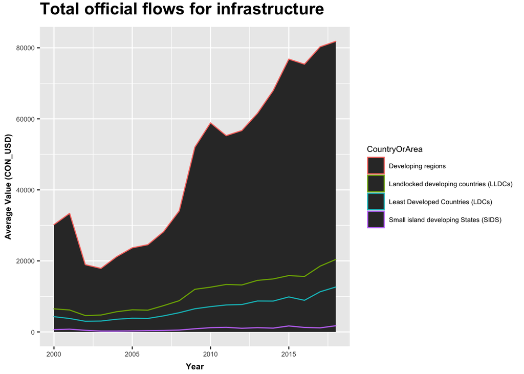

```r
data_rank_top %>% ggplot(aes(x=Year,y = AverageValue, color=CountryOrArea)) +
  geom_area() +
  theme (text = element_text(size=8)) +
    ggtitle ("Total official flows for infrastructure") +
    theme (plot.title = element_text(size=rel(2),
                                  vjust=2,
                                  face="bold",
                                  color="black",
                                  lineheight=1.5)) +
    labs(x = "Year",y = "Average Value (CON_USD)") +
    theme(axis.title.x = element_text(face="bold", vjust=-0.5, colour="black", size=rel(1))) +
    theme(axis.title.y = element_text(face="bold", vjust=1.5, colour="black", size=rel(1)))
```

Como se puede observar ha habido un aumento considerable de la inversión, sobretodo en las regiones en desarrollo. Tal y como se pretendía en este objetivo.

# 4. ¿CUALES SON LOS PAÍSES CON PEORES VALORES DE MEDIA PARA 2018?

Como podemos observar el 25% de los países tiene un valor medio por debajo de 10.405 CON_USD

Seleccionamos el último año de nuestros datos para observar qué países están más lejos del target, de este modo podremos centrarnos en ellos y analizarlos a fondo

```r
tail(data_rank)
```

```
## # A tibble: 6 x 8
## # Groups:   Year [1]
##    Year Target    Indicator    Measure    CountryOrArea AverageValue Units  rank
##   <dbl> <chr>     <chr>        <chr>      <chr>                <dbl> <chr> <int>
## 1  2018 TARGET 9~ INDICATOR 9~ Total off~ Dominica              4.94 CON_~   119
## 2  2018 TARGET 9~ INDICATOR 9~ Total off~ Antigua and ~         4.61 CON_~   120
## 3  2018 TARGET 9~ INDICATOR 9~ Total off~ Palau                 1.65 CON_~   121
## 4  2018 TARGET 9~ INDICATOR 9~ Total off~ Democratic P~         1.51 CON_~   122
## 5  2018 TARGET 9~ INDICATOR 9~ Total off~ Saint Lucia           1.39 CON_~   123
## 6  2018 TARGET 9~ INDICATOR 9~ Total off~ Equatorial G~         0.04 CON_~   124
```

GUINEA ECUATORIAL y SANTA LUCÍA son algunos países de la cola. Vamos a estudiar su progreso durante los años y obtendremos una vista de su tendencia.

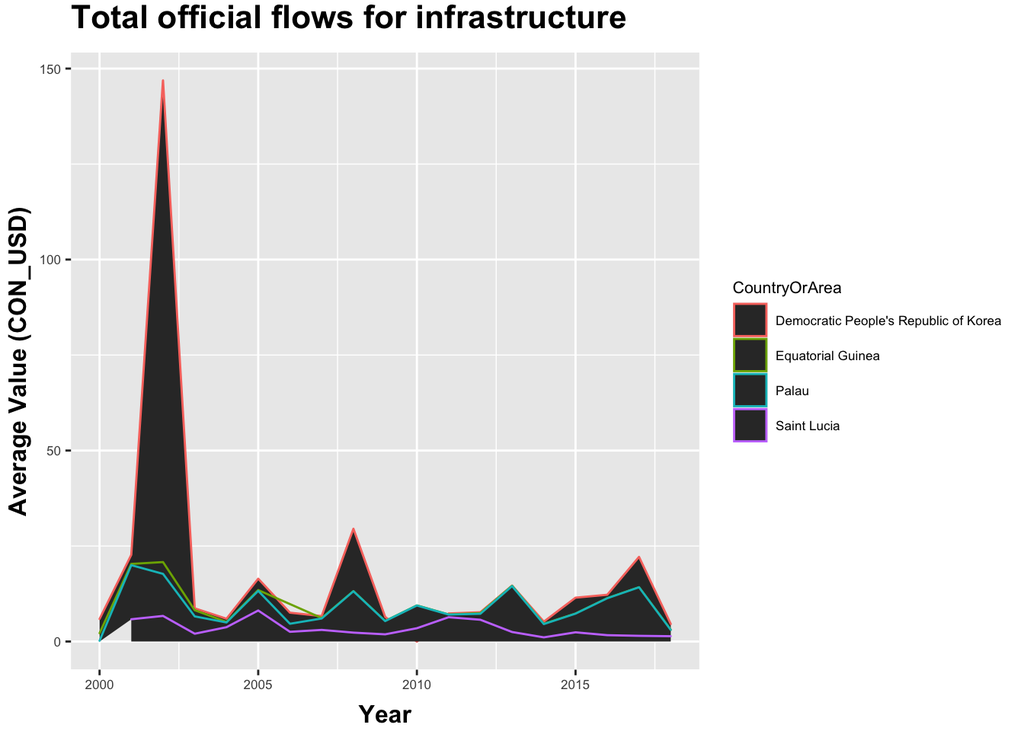

```r
data_rank_tail <- goal9t %>%
  filter(CountryOrArea %in% c("Palau","Equatorial Guinea", "Democratic People's Republic of Korea","Saint Lucia"))

data_rank_tail %>% ggplot(aes(x=Year,y = AverageValue, color=CountryOrArea)) + geom_area() +
  theme (text = element_text(size=8)) +
    ggtitle ("Total official flows for infrastructure") +
    theme (plot.title = element_text(size=rel(2),
                                  vjust=2,
                                  face="bold",
                                  color="black",
                                  lineheight=1.5)) +
    labs(x = "Year",y = "Average Value (CON_USD)") +
    theme(axis.title.x = element_text(face="bold", vjust=-0.5, colour="black", size=rel(1.5))) +
    theme(axis.title.y = element_text(face="bold", vjust=1.5, colour="black", size=rel(1.5)))
```

Estos países describen un comportamiento de negativo

# 5. ¿CUAL ES LA TENDENCIA MUNDIAL?

## 5.1 PREPROCESAMIENTO

¿Están los datos balancedos por años?

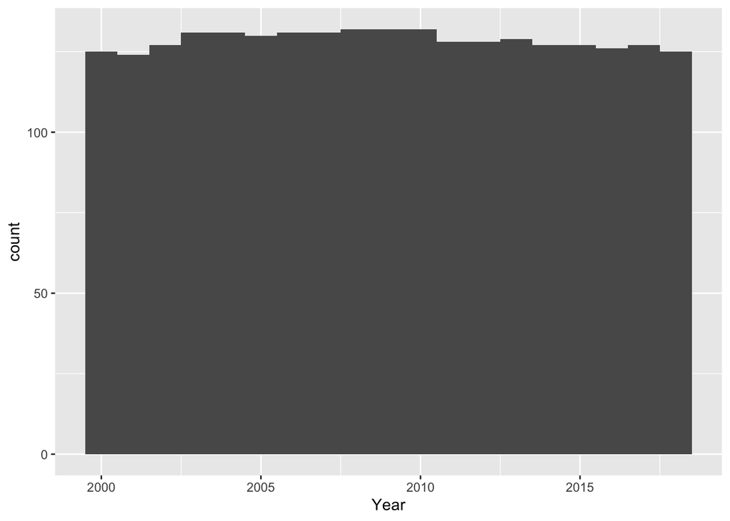

```r
goal9r <- goal9t %>%
  complete(Year, AverageValue)

ggplot(goal9r, aes(x=Year)) +
  geom_histogram(binwidth = 1)
```

Sí, parece que tenemos aproximadamente la misma cantidad de datos por año.

Estudiamos los outliers.

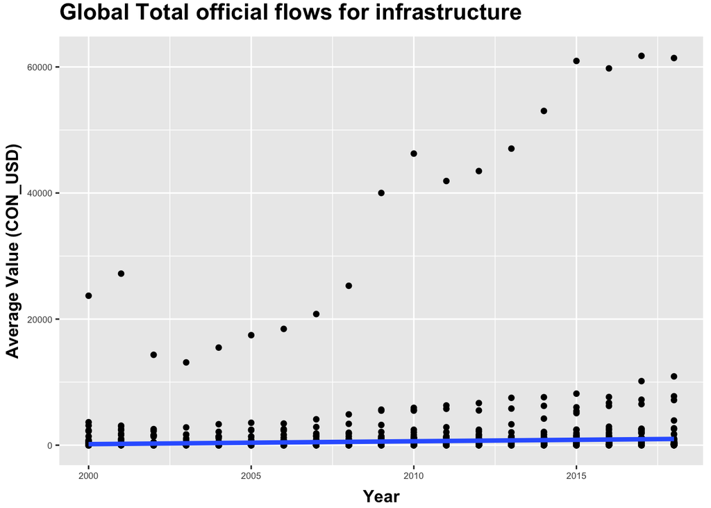

```r
ggplot(goal9r, aes(x=Year, y=AverageValue)) +
  geom_point() + geom_smooth(method="lm", size=1.5) +
  theme (text = element_text(size=8)) +
    ggtitle ("Global Total official flows for infrastructure") +
    theme (plot.title = element_text(size=rel(2),
                                  vjust=2,
                                  face="bold",
                                  color="black",
                                  lineheight=1.5)) +
    labs(x = "Year",y = "Average Value (CON_USD)") +
    theme(axis.title.x = element_text(face="bold", vjust=-0.5, colour="black", size=rel(1.5))) +
    theme(axis.title.y = element_text(face="bold", vjust=1.5, colour="black", size=rel(1.5)))
```

Estudiamos los valores atípicos y los eliminamos para poder observar mejor el grueso de los datos.

```r
# se debe tener la variable en forma de vector
outlier <- goal9r$AverageValue

# identificar cuartiles y rango intercuartil
Q <- quantile(outlier, probs=c(.05, .95), na.rm = TRUE)
iqr <- IQR(outlier, na.rm = TRUE)

up <-  Q[2]+1.5*iqr # Rango superior
low <- Q[1]-1.5*iqr # Rango inferior

# filtrar valores dentro del rango
goal9r_deleted<- goal9r %>% filter(AverageValue > low & AverageValue < up)
```

## 5.2 VISUALIZACIÓN

### 5.2.1 VISUALIZACIÓN GLOBAL

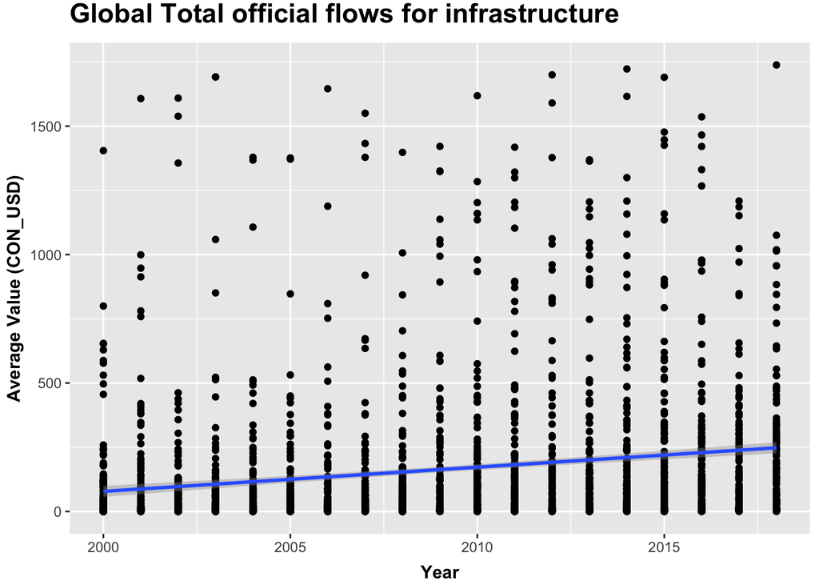

```r
ggplot(goal9r_deleted, aes(x=Year, y=AverageValue)) +
  geom_point() + geom_smooth(method="lm", size=1) +
  ggtitle ("Global Total official flows for infrastructure") +
    theme (plot.title = element_text(size=rel(1.5),
                                  vjust=2,
                                  face="bold",
                                  color="black",
                                  lineheight=1.5)) +
    labs(x = "Year",y = "Average Value (CON_USD)") +
    theme(axis.title.x = element_text(face="bold", vjust=-0.5, colour="black", size=rel(1))) +
    theme(axis.title.y = element_text(face="bold", vjust=1.5, colour="black", size=rel(1)))
```

###5.2.2 MOZAMBIQUE: VISUALIZACIÓN

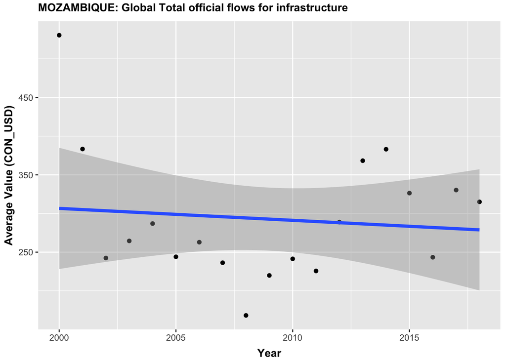

```r
mz <- goal9r %>% filter(CountryOrArea == "Mozambique")
ggplot(mz, aes(x=Year, y=AverageValue)) +
  geom_point() + geom_smooth(method="lm", size=1.5) +
  ggtitle ("MOZAMBIQUE: Global Total official flows for infrastructure") +
    theme (plot.title = element_text(size=rel(1),
                                  vjust=2,
                                  face="bold",
                                  color="black",
                                  lineheight=1.5)) +
    labs(x = "Year",y = "Average Value (CON_USD)") +
    theme(axis.title.x = element_text(face="bold", vjust=-0.5, colour="black", size=rel(1))) +
    theme(axis.title.y = element_text(face="bold", vjust=1.5, colour="black", size=rel(1)))
```

Se observa una ligera tendencia al alza. Los países en general cada vez están aumentando el flujo monetario para mejorar sus infraestructuras.

En el caso de Mozambique va decreciendo ligeramente.